# Practical Machine Learning Course Project

K. Maxwell

May 6, 2020

## R Markdown

This is the course project for Practical Machine Learning. Devices such as Jawbone Up, Fitbit, and Nike FuelBand are now making it possible to easily track and obtain personal data on self movement. While it is easily able to obtain data on the quantity of activities performed it is rarely quantified how well the activity is performed. The goal of this project is the use data from accelerometers on the belt, forearm, arm, and dumbell of six participants who have been asked to perform barebell lifts correctly and incorrectly five different ways.

## Running Necessary Packages

```r
library(e1071)
library(caret)
library(rpart)
library(rattle)
library(randomForest)
library(knitr)
```

## Loading the Data

The training and testing datasets are found at the following urls. The data is titled Assignment_Training and Assignment_Testing

```r
train_url <- "http://d396qusza40orc.cloudfront.net/predmachlearn/pml-training.csv"
test_url  <- "http://d396qusza40orc.cloudfront.net/predmachlearn/pml-testing.csv"

Assignment_Training <- read.csv(url(train_url))
Assignment_Testing <- read.csv(url(test_url))
colnames(Assignment_Training)
```

```
##   [1] "X"                        "user_name"
##   [3] "raw_timestamp_part_1"     "raw_timestamp_part_2"
##   [5] "cvtd_timestamp"           "new_window"
##   [7] "num_window"               "roll_belt"
##   [9] "pitch_belt"               "yaw_belt"
##  [11] "total_accel_belt"         "kurtosis_roll_belt"
##  [13] "kurtosis_picth_belt"      "kurtosis_yaw_belt"
##  [15] "skewness_roll_belt"       "skewness_roll_belt.1"
##  [17] "skewness_yaw_belt"        "max_roll_belt"
##  [19] "max_picth_belt"           "max_yaw_belt"
##  [21] "min_roll_belt"            "min_pitch_belt"
##  [23] "min_yaw_belt"             "amplitude_roll_belt"
##  [25] "amplitude_pitch_belt"     "amplitude_yaw_belt"
##  [27] "var_total_accel_belt"     "avg_roll_belt"
##  [29] "stddev_roll_belt"         "var_roll_belt"
```

[output cut: 65 more lines]

```r
dim(Assignment_Training)
```

```
## [1] 19622   160
```

```r
dim(Assignment_Testing)
```

```
## [1]  20 160
```

## Data Preperation and Cleaning

Some necessary data preparation is required to clean the data and get it ready for use in the models. The first step is to remove the NAs. The second step is to remove the first 7 varaiables as they will provide no additional value to the modoels.

```r
# Data prep: remove NAs
nas <- sapply(Assignment_Training, function(x) mean(is.na(x))) > 0.95
Assignment_Training <- Assignment_Training[,nas == FALSE]
Assignment_Testing <- Assignment_Testing[,nas == FALSE]
dim(Assignment_Training)
```

```
## [1] 19622    93
```

```r
# Remove columns 1-7
Assignment_Training <- Assignment_Training[,-c(1:7)]
Assignment_Testing <- Assignment_Testing [,-c(1:7)]
dim(Assignment_Training)
```

```
## [1] 19622    86
```

## Partitioning the Data into Training and Cross-validation Sets

The training dataset is then partitioned (70%/30%) to create a training dataset and a cross-validation dataset.

```r
intrain = createDataPartition(Assignment_Training$classe, p=0.70, list = FALSE)
Training_final = Assignment_Training[intrain,]
Testing_final  = Assignment_Training[-intrain,]

colnames(Training_final)
```

```
##  [1] "roll_belt"               "pitch_belt"
##  [3] "yaw_belt"                "total_accel_belt"
##  [5] "kurtosis_roll_belt"      "kurtosis_picth_belt"
##  [7] "kurtosis_yaw_belt"       "skewness_roll_belt"
##  [9] "skewness_roll_belt.1"    "skewness_yaw_belt"
## [11] "max_yaw_belt"            "min_yaw_belt"
## [13] "amplitude_yaw_belt"      "gyros_belt_x"
## [15] "gyros_belt_y"            "gyros_belt_z"
## [17] "accel_belt_x"            "accel_belt_y"
## [19] "accel_belt_z"            "magnet_belt_x"
## [21] "magnet_belt_y"           "magnet_belt_z"
## [23] "roll_arm"                "pitch_arm"
## [25] "yaw_arm"                 "total_accel_arm"
## [27] "gyros_arm_x"             "gyros_arm_y"
## [29] "gyros_arm_z"             "accel_arm_x"
```

[output cut: 28 more lines]

```r
dim(Training_final)
```

```
## [1] 13737    86
```

```r
dim(Testing_final)
```

```
## [1] 5885   86
```

## Remove Near Zero Variance

The next step is to remove any variable with near zero variance. These variables have extremely low variances and as a result have very little information because they mostly consist of a single value (e.g. zero).

```r
 NZV <- nearZeroVar(Training_final)
    Training_final <- Training_final[, -NZV]
  Testing_final  <- Testing_final[, -NZV]
  dim(Training_final)
```

```
## [1] 13737    53
```

## Predicting with a Decision Tree

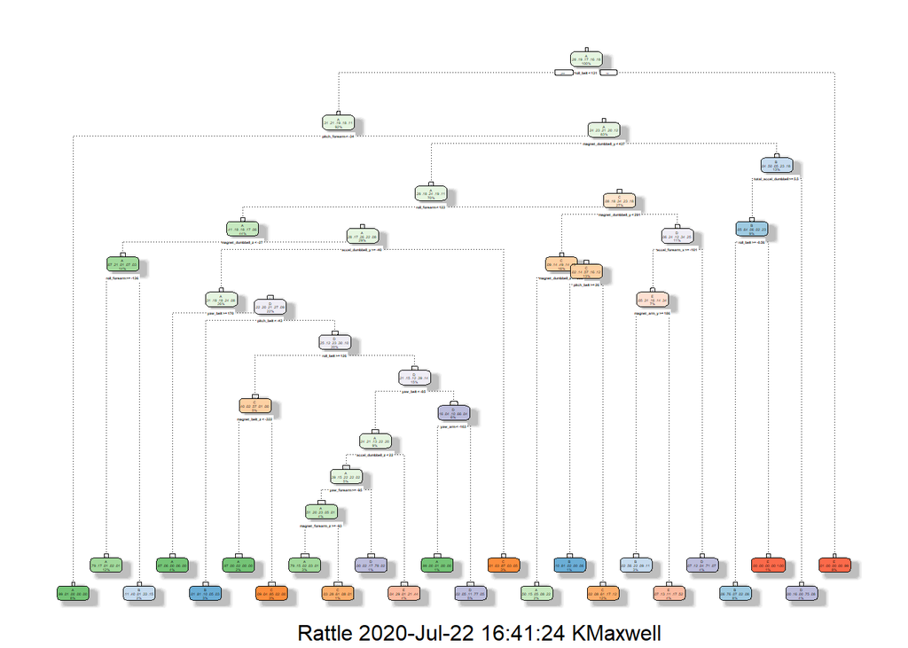

```r
set.seed((12345))
modelDT <- rpart(classe ~., data = Training_final, method = "class")

fancyRpartPlot(modelDT)
```

## Random Forest

```r
set.seed(12345)
controlRF <- trainControl(method="cv", number=3, verboseIter=FALSE)
modelRandomForest <- train(classe ~., method='rf', data = Training_final, trControl=controlRF)
modelRandomForest$finalModel
```

```
##
## Call:
##  randomForest(x = x, y = y, mtry = param$mtry)
##                Type of random forest: classification
##                      Number of trees: 500
## No. of variables tried at each split: 27
##
##         OOB estimate of  error rate: 0.7%
## Confusion matrix:
##      A    B    C    D    E class.error
## A 3899    7    0    0    0 0.001792115
## B   19 2632    6    1    0 0.009781791
## C    0   11 2376    9    0 0.008347245
## D    0    0   30 2220    2 0.014209591
## E    0    1    4    6 2514 0.004356436
```

## Selecting the Best Model

```r
BestModel <- predict(modelRandomForest, newdata = Assignment_Testing)
BestModel
```

```
##  [1] B A B A A E D B A A B C B A E E A B B B
## Levels: A B C D E
```